# **An Analysis of New York City's Motor Vehicle Collisions**

# **Primary analysis**

Our question was, **"What are key motor vehicle collision risk factors that everyday people can avoid?"** To best answer this question we decided to use a **Logistic Regression** machine learning technique. This technique will help **classify** collisions based on severity, location, and time of day. Then with our data classified into such understandable factors we can draw conclusions on major risk factors and how people can avoid them. For example, if it seems rush hour correlates to a significant increase in severe crashes we can suggest rush hour as a key risk factor and recommend people stay off roads during rush hour whenever possible to avoid it.

```
SEVERE
0    0.765365
1    0.234635
Name: proportion, dtype: float64
Classification Report:
              precision    recall  f1-score   support

           0       0.79      0.43      0.55    289770
           1       0.25      0.64      0.36     88439

    accuracy                           0.47    378209
   macro avg       0.52      0.53      0.46    378209
weighted avg       0.67      0.47      0.51    378209
```

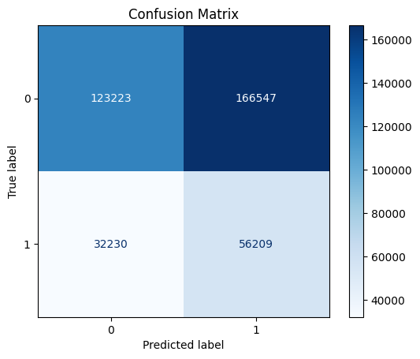

```python
# Loading dataset
crashes_df = pd.read_csv('Motor_Vehicles_Collisions.csv', low_memory=False)

# Converting dates and times
crashes_df['CRASH DATE'] = pd.to_datetime(crashes_df['CRASH DATE'], errors='coerce')
crashes_df['CRASH TIME'] = pd.to_datetime(crashes_df['CRASH TIME'], errors='coerce', format='%H:%M')
crashes_df['CRASH HOUR'] = crashes_df['CRASH TIME'].dt.hour
crashes_df['DAY_OF_WEEK'] = crashes_df['CRASH DATE'].dt.dayofweek
crashes_df['IS_WEEKEND'] = crashes_df['DAY_OF_WEEK'] >= 5
crashes_df['IS_RUSH_HOUR'] = crashes_df['CRASH HOUR'].between(6, 9) | crashes_df['CRASH HOUR'].between(15, 18)
# ------------------------------------------------------------------------------------------------------------------ #


# For Machine Learning, We will use Logistic Regression
from sklearn.linear_model import LogisticRegression
from sklearn.model_selection import train_test_split

# Binary Classification - 1 if persons were injured or killed. 0 if not.
crashes_df['SEVERE'] = (
    (crashes_df['NUMBER OF PERSONS INJURED'].fillna(0) > 0) |
    (crashes_df['NUMBER OF PERSONS KILLED'].fillna(0) > 0)
).astype(int)


# Drop rows with missing boroughs
crashes_df = crashes_df.dropna(subset=['BOROUGH'])


# Prepare features for model
features = ['CRASH HOUR', 'DAY_OF_WEEK', 'IS_WEEKEND', 'IS_RUSH_HOUR', 'BOROUGH']
X = crashes_df[features].copy()
X = pd.get_dummies(X, columns=['BOROUGH'])
y = crashes_df['SEVERE']

# Train / test split
# 75% training and 25% test:
X_train, X_test, y_train, y_test = train_test_split(X, y, test_size=0.25, random_state=42)

# Fit the model
model = LogisticRegression(class_weight='balanced', max_iter=1000)
model.fit(X_train, y_train)


# Print severe data
print(crashes_df['SEVERE'].value_counts(normalize=True))
# ------------------------------------------------------------------------------------------------------------------ #


# Classification Report
from sklearn.metrics import classification_report

# Predict on test set
y_pred = model.predict(X_test)

# Print classification report
print("Classification Report:")
print(classification_report(y_test, y_pred))


# ------------------------------------------------------------------------------------------------------------------ #


# Confusion Matrix
from sklearn.metrics import ConfusionMatrixDisplay

ConfusionMatrixDisplay.from_estimator(model, X_test, y_test, cmap="Blues")
plt.title("Confusion Matrix")
plt.show()
```

# **Visualization**

To better understand how the severity of motor vehicle crashes varies across time and location, we created the following plot.

This line chart visualizes the percentage of crashes that resulted in injury or death ("SEVERE") for each hour of the day, broken down by New York's five boroughs. We also highlight rush hour periods.

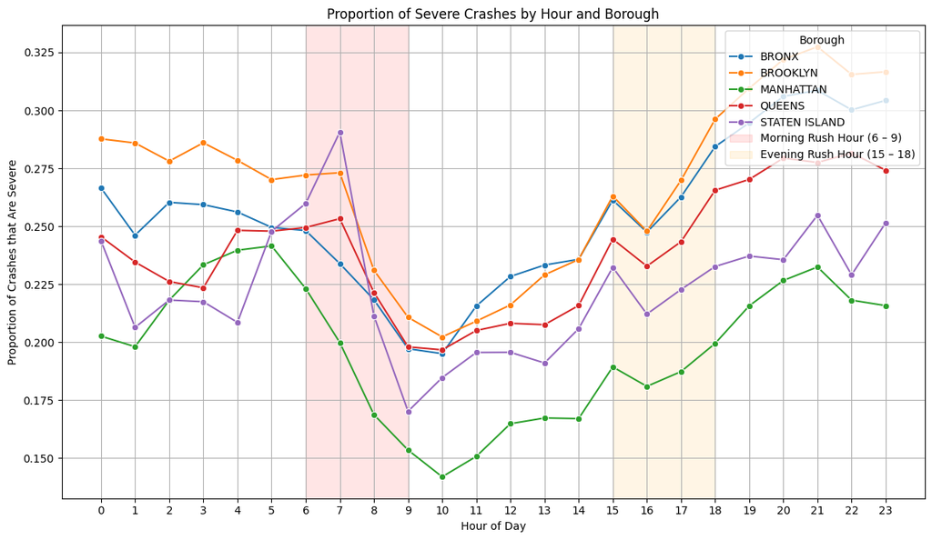

```python
grouped = crashes_df.groupby(['CRASH HOUR', 'BOROUGH'])['SEVERE'].mean().reset_index()

# Plot
plt.figure(figsize=(12, 7))
sns.lineplot(data=grouped, x='CRASH HOUR', y='SEVERE', hue='BOROUGH', marker="o")
plt.axvspan(6, 9, color='red', alpha=0.1, label='Morning Rush Hour (6 – 9)')
plt.axvspan(15, 18, color='orange', alpha=0.1, label='Evening Rush Hour (15 – 18)')
plt.title("Proportion of Severe Crashes by Hour and Borough")
plt.xlabel("Hour of Day")
plt.ylabel("Proportion of Crashes that Are Severe")
plt.xticks(range(0, 24))
plt.legend(loc='upper right', title="Borough")
plt.grid(True)
plt.tight_layout()
plt.show()
```

# **Insights and Conclusions**

**Insights:**

Early morning (12 AM - 6 AM)

- Manhattan, Queens, Staten Island - These 3 boroughs appear to have decreasing severe accident proportions before they increase.
- Brooklyn, Brox - These 2 boroughs have stable but slightly decreasing severe accident proportions.

Morning rush (6 AM - 9 AM)

- Staten Island - There is a significant increase in the proportion of severe accidents proportions until 7 am before sharply declining.
- Brooklyn, Queens - There is a slight increase in the proportion of severe accidents proportions until 7 am before consistently declining.
- Brox, Manhattan - There is a consistent decline in the proportion of severe accidents proportions.

Afternoon rush(3 PM - 6 PM)

- All Broughs - There is a local peak in the proportion of severe accidents around 3 PM, after which it decreases until 4 PM, after which it consistently increases.

Night time (6 PM - 12 AM)

- Brooklyn, Bronx, Staten Island - The proportion of severe accidents increases until 9 PM before decreasing until 10 PM and increasing again.
- Manhattan - The proportion of severe accidents increases until 9 PM, before it decreases.
- Queens - The proportion of severe accidents increases until 8 PM before it stabilizes.

**Conclusions:**

*For a reader:

-An uninformed reader will have obtained an understanding of when and where crashes are most likely to be dangerous.

-A reader with prior knowledge will gain additional depth on the topic through modeled insights, quantifiable risk breakdowns, and borough-level comparisons.

Both types of readers will be aware of actionable insights and can make some for themselves as well.